# 23 - Actividad 08 en R Markdown

Palomeque Jonathan Manuel

2024-04-28

En esta actividad agregare anotaciones a una visualizacion de datos con ggplot2. Tambien guardare imagenes de visualizaciones de ggplot2 para poder agregarlas directamente en presentaciones.

## Escenario

Como analista de datos en una empresa de reservas hoteleras, has estado creando visualizaciones en `R` con el paquete `ggplot2` para compartir conclusiones sobre los datos con los interesados. Despues de crear una serie de visualizaciones usando estetica y filtros de `ggplot()` y `ggplot2`, tu interesado te pide que agregues anotaciones a tus visualizaciones para ayudar a explicar tus resultados en una presentacion. Afortunadamente, `ggplot2` tiene funciones de anotacion integradas.

## Paso 1: Importar los datos

```r
library('tidyverse')
reservas_hotel <- read_csv("hotel_bookings.csv", locale = readr::locale(encoding = "latin1"))
```

## Paso 2: Refrescar la memoria

Obtener una muestra de los datos y tener una vista previa los nombres de todas las columnas:

```r
head(reservas_hotel)
```

```
## # A tibble: 6 × 32
##   hotel        is_canceled lead_time arrival_date_year arrival_date_month
##   <chr>              <dbl>     <dbl>             <dbl> <chr>
## 1 Resort Hotel           0       342              2015 July
## 2 Resort Hotel           0       737              2015 July
## 3 Resort Hotel           0         7              2015 July
## 4 Resort Hotel           0        13              2015 July
## 5 Resort Hotel           0        14              2015 July
## 6 Resort Hotel           0        14              2015 July
## # ℹ 27 more variables: arrival_date_week_number <dbl>,
## #   arrival_date_day_of_month <dbl>, stays_in_weekend_nights <dbl>,
## #   stays_in_week_nights <dbl>, adultos <dbl>, `ni\u0096os` <dbl>,
## #   `beb\u008es` <dbl>, comida <chr>, `pa\u0092s` <chr>, market_segment <chr>,
## #   distribution_channel <chr>, is_repeated_guest <dbl>,
## #   previous_cancellations <dbl>, previous_bookings_not_canceled <dbl>,
## #   reserved_room_type <chr>, assigned_room_type <chr>, …
```

```r
colnames(reservas_hotel)
```

```
##  [1] "hotel"                          "is_canceled"
##  [3] "lead_time"                      "arrival_date_year"
##  [5] "arrival_date_month"             "arrival_date_week_number"
##  [7] "arrival_date_day_of_month"      "stays_in_weekend_nights"
##  [9] "stays_in_week_nights"           "adultos"
## [11] "ni\u0096os"                     "beb\u008es"
## [13] "comida"                         "pa\u0092s"
## [15] "market_segment"                 "distribution_channel"
## [17] "is_repeated_guest"              "previous_cancellations"
## [19] "previous_bookings_not_canceled" "reserved_room_type"
## [21] "assigned_room_type"             "booking_changes"
## [23] "deposit_type"                   "agente"
## [25] "empresa"                        "days_in_waiting_list"
## [27] "customer_type"                  "adr"
## [29] "required_car_parking_spaces"    "total_of_special_requests"
## [31] "reservation_status"             "reservation_status_date"
```

## Paso 3: Realizar anotaciones en tu grafico

Tu interesado te menciona que les gustaría que compartieras la visualización desglosando el tipo de pago por ciudad, ya que esto ayudará a determinar cómo la empresa dirigirá las promociones en el futuro. Te piden que crees una versión limpia y etiquetada, y que la guardes como un archivo .png para que ellos puedan incluirla en una presentación

Graficos de barras de city_hotel y resort_hotel. En el eje x esta market_segment y en el eje Y esta count:

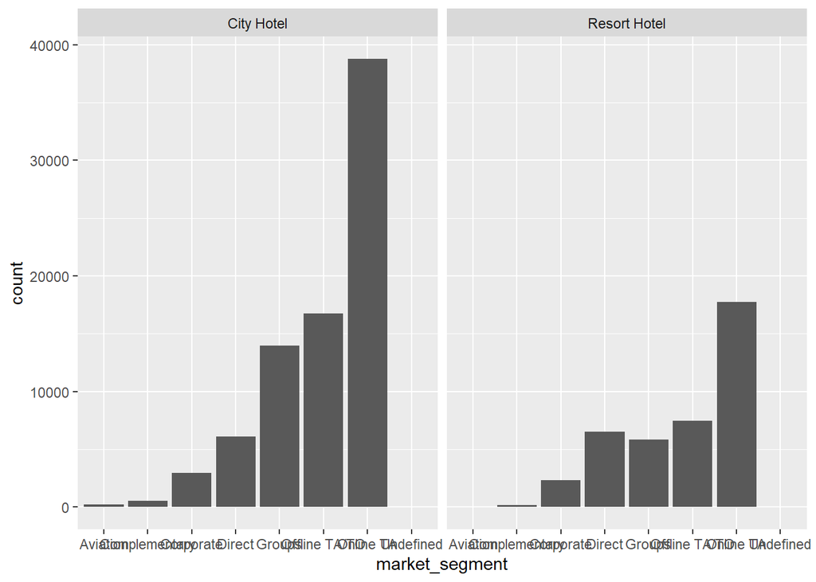

```r
ggplot(data = reservas_hotel) +
  geom_bar(mapping = aes(x = market_segment)) +
  facet_wrap(~hotel)
```

En esta visualizacion, no queda claro de donde provienen los datos, cual es la conclusion clave o ni siquiera que muestran los datos. Para explicar todo eso, puedes aprovechar las anotaciones en `ggplot2`

Agregare un titulo (Segmentos de mercado) y diferenciare los graficos por color para darle una mayor claridad a la visualizacion de los datos a los interesados:

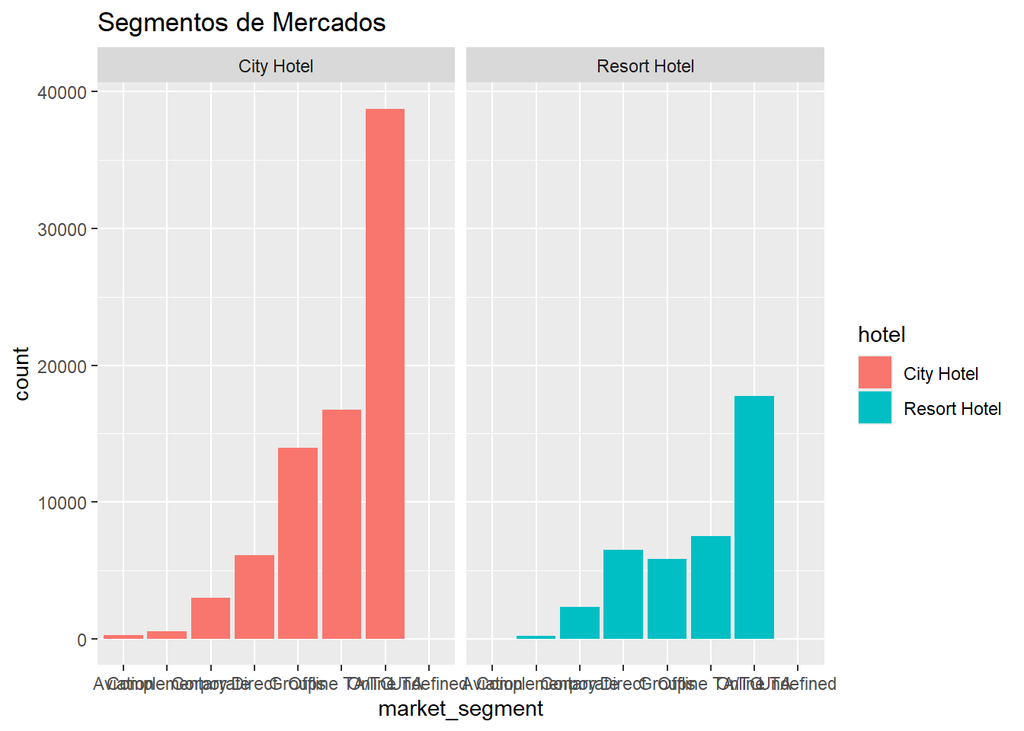

```r
ggplot(data = reservas_hotel) +
  geom_bar(mapping = aes(x = market_segment, fill= hotel)) +
  facet_wrap(~hotel) +
  labs(title="Segmentos de Mercados")
```

Quierro agregar la informacion de sobre cual periodo son los datos, para lo cual averiguare de cuando son los datos y los guardaré en variables:

Año mas antiguo:

```r
fecha_minima <- min(reservas_hotel$arrival_date_year)
```

Año mas actual:

```r
fecha_maxima <- max(reservas_hotel$arrival_date_year)
```

Ahora, agrego un subtitulo usando `subtitle=` en la funcion `labs()`. Luego, usare la funcion `paste0()` para usar mis variables recien creadas en mis etiquetas. Esto es muy util, ya que si los datos se actualizan y se agregan datos mas recientes, no tendre que modificar el codigo, porque las variables son dinamicas:

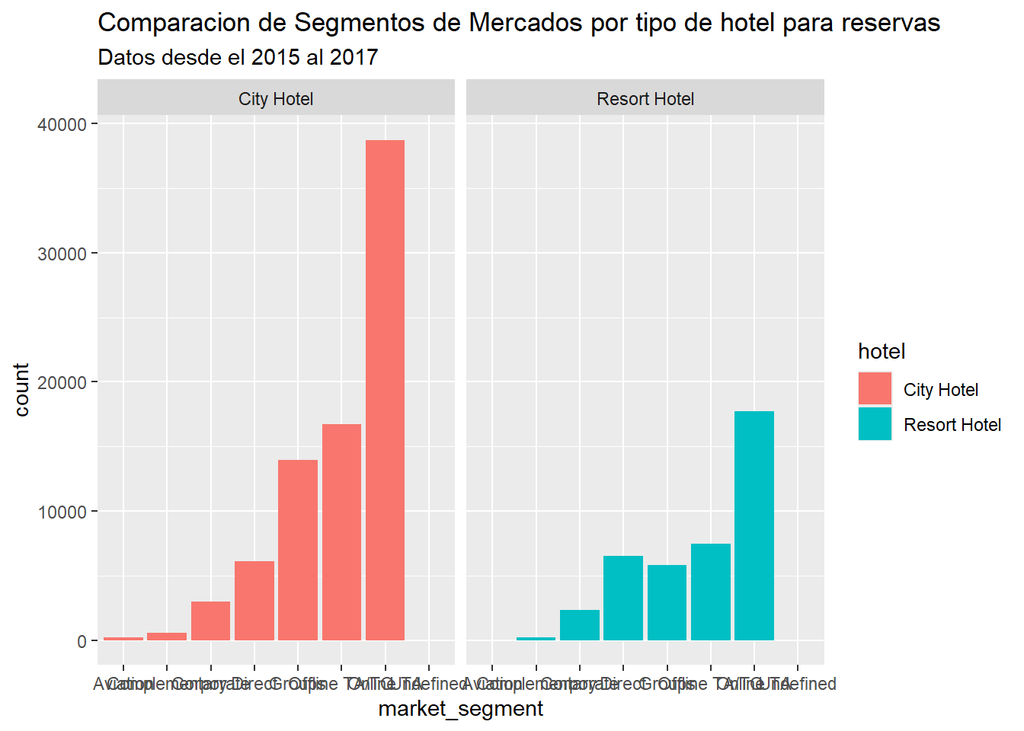

```r
ggplot(data = reservas_hotel) +
  geom_bar(mapping = aes(x = market_segment, fill= hotel)) +
  facet_wrap(~hotel) +
  labs(title="Comparacion de Segmentos de Mercados por tipo de hotel para reservas",
       subtitle =  paste0("Datos desde el ", fecha_minima, " al ", fecha_maxima))
```

Voy a modificar el `subtitle` (subtitulo) para que se transforme en una `caption` (leyenda), que aparecera en la esquina inferior derecha.

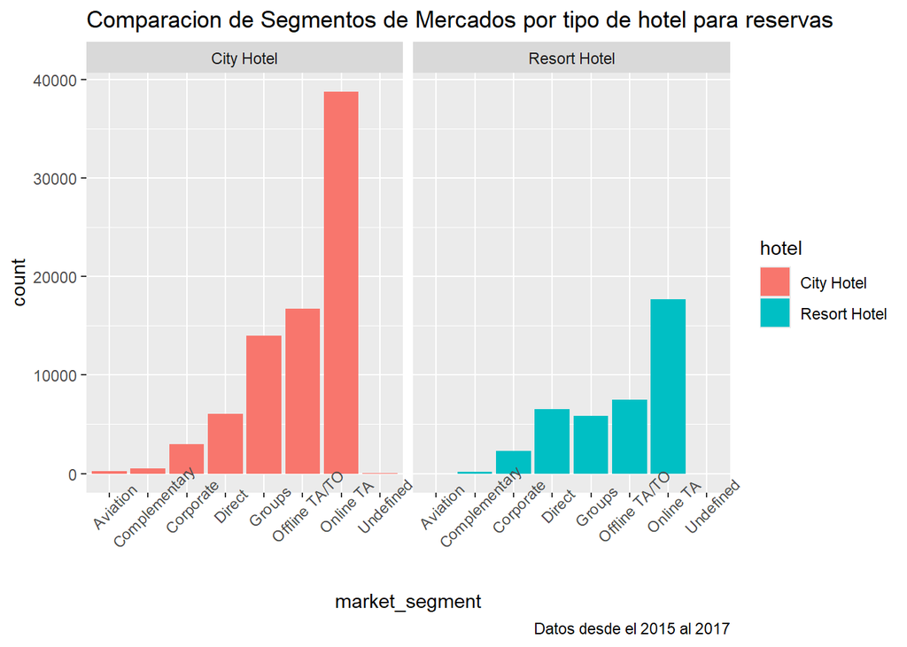

```r
ggplot(data = reservas_hotel) +
  geom_bar(mapping = aes(x = market_segment, fill= hotel)) +
  facet_wrap(~hotel) +
  theme(axis.text.x = element_text(angle = 45)) +
  labs(title="Comparacion de Segmentos de Mercados por tipo de hotel para reservas",
       caption=paste0("Datos desde el ", fecha_minima, " al ", fecha_maxima))
```

Limpiare las etiquetas del eje x e y para asegurarme de que sean claras. Para hacerlo, agregare la funcion `labs()` y usare `x=` e `y=`

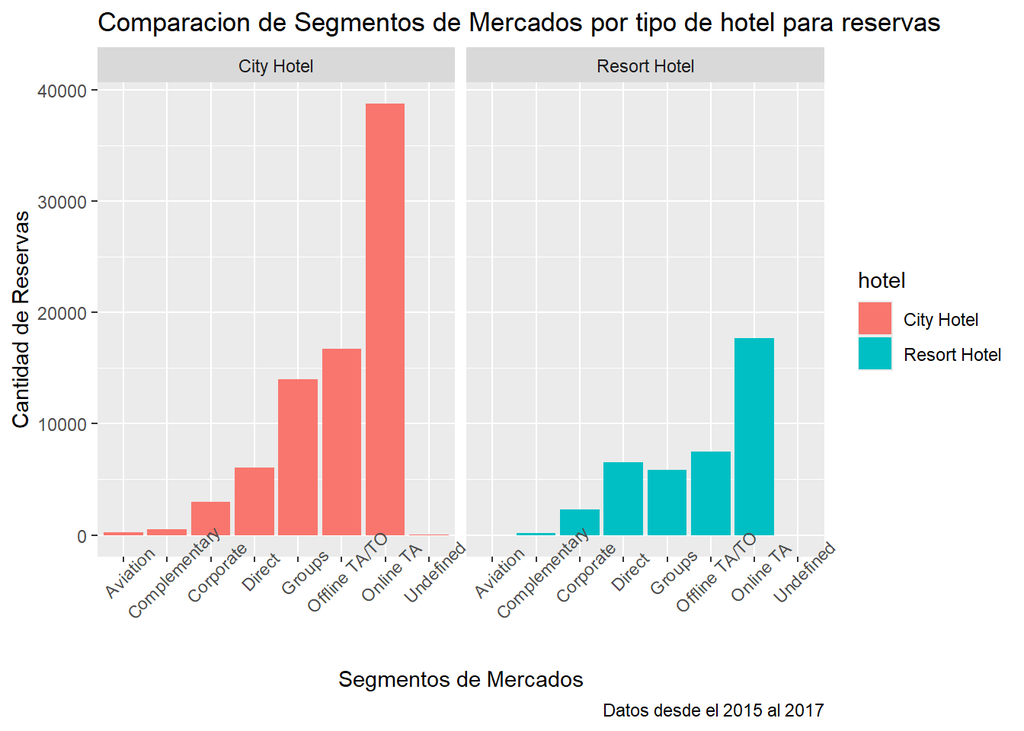

```r
ggplot(data = reservas_hotel) +
  geom_bar(mapping = aes(x = market_segment, fill= hotel)) +
  facet_wrap(~hotel) +
  theme(axis.text.x = element_text(angle = 45)) +
  labs(title="Comparacion de Segmentos de Mercados por tipo de hotel para reservas",
       caption=paste0("Datos desde el ", fecha_minima, " al ", fecha_maxima),
       x="Segmentos de Mercados",
       y="Cantidad de Reservas")
```

## Paso 5: Guardar tu grafico

usare la funcion `ggsave()` para guardar el imagen como un 7x7

```r
ggsave('grafico2.png',
       width= 7,
       height= 7)
```